# Yulu_HypothesisTesting

# Insights:

Balanced usage: People might rent cycles for both commuting (on working days) and leisure (on non-working days), leading to no strong difference.

Other stronger influences: Factors like weather, holidays, or time of year might play a bigger role in rental patterns than simply whether a day is classified as a "working day."

2. No. of cycles rented similar or different in different seasons

Null Hypothesis (H₀): The number of cycles rented does not significantly differ across seasons.

Alternative Hypothesis (H₁): The number of cycles rented significantly differs across seasons.

```
Season 1
####################################################################################################
```

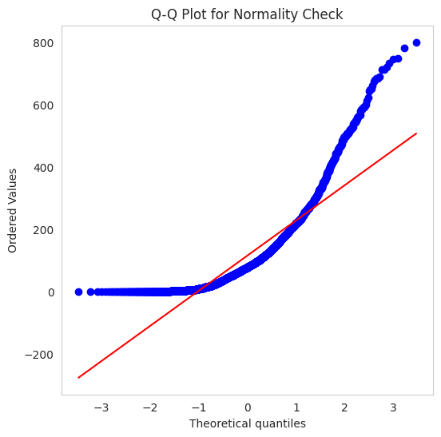

```
Normality Test:      Kolmogorov-Smirnov Test
Test Statistic:      1.7860e-01
P-value:             2.0076e-75

Reject H₀: Data is **not normally distributed**.


Season 2
####################################################################################################
```

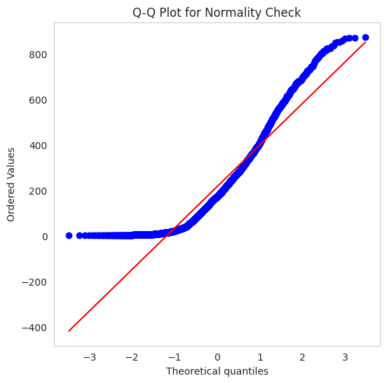

```
Normality Test:      Kolmogorov-Smirnov Test
Test Statistic:      1.3224e-01
P-value:             3.8735e-42

Reject H₀: Data is **not normally distributed**.


Season 3
####################################################################################################
```

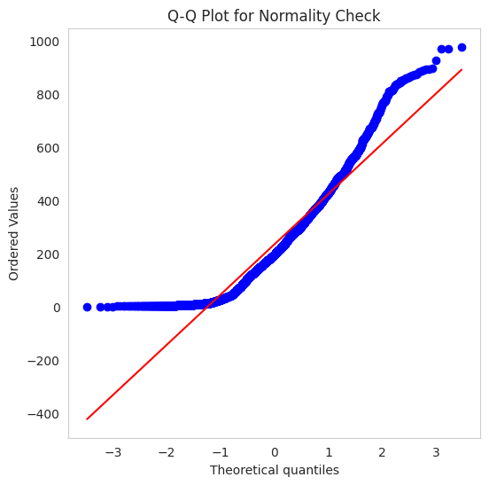

```
Normality Test:      Kolmogorov-Smirnov Test
Test Statistic:      1.1822e-01
P-value:             9.7900e-34

Reject H₀: Data is **not normally distributed**.


Season 4
####################################################################################################
```

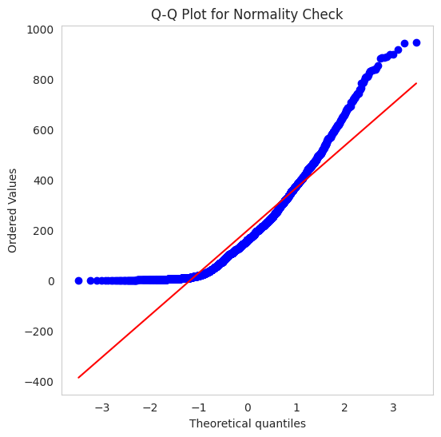

```
Normality Test:      Kolmogorov-Smirnov Test
Test Statistic:      1.3250e-01
P-value:             2.5790e-42

Reject H₀: Data is **not normally distributed**.




Variance Test:       Levene's Test
Test Statistic:      1.8777e+02
P-value:             1.0147e-118

Reject H₀: Variances are not equal.
```

```python
is_normal = True

for season in df['season'].unique():
    print(f"Season {season}")
    normal = normality_test(df[df['season'] == season]['count'])
    if not normal:
        is_normal = False

variance_test('season','count', is_normal)
```

Both normality and variance assumptions failed. Even so, lets use ANOVA as mentioned in question

```python
test_stat, p_value = stats.f_oneway(*[group['count'] for _, group in df.groupby('season')])
print("\n")
print("*"*100)
print(f"{'ANOVA Test:':^100}")
print(f"{'Test Statistic':<20} {test_stat:<10.4e}")
print(f"{'P-value':<20} {p_value:<10.4e}")

if p_value < 0.05:
    print("\nReject H₀: The number of cycles rented significantly differs across seasons.")
else:
    print("\nFail to reject H₀: The number of cycles rented does not significantly differ across seasons.")
print("*"*100)
print("\n")
```

```
                                            ANOVA Test:
Test Statistic       2.3695e+02
P-value              6.1648e-149

Reject H₀: The number of cycles rented significantly differs across seasons.
```

# Insights:

Seasonal Variation: The significant result from the ANOVA test indicates that the number of cycles rented varies across different seasons, suggesting that external factors like weather, holidays, or events could influence bike rentals.

Data Implications: Businesses or city planners can use this insight to optimize cycle availability and marketing efforts, tailoring strategies to each season’s demand patterns.

Actionable Strategy: Prepare for higher rentals during peak seasons and plan for lower demand periods by adjusting inventory and pricing strategies accordingly.

3. No. of cycles rented similar or different in different weather

Null Hypothesis (H₀): The number of cycles rented does not significantly differ across different weathers.

Alternative Hypothesis (H₁): The number of cycles rented significantly differs across different weathers.

```
Weather 1
####################################################################################################
```

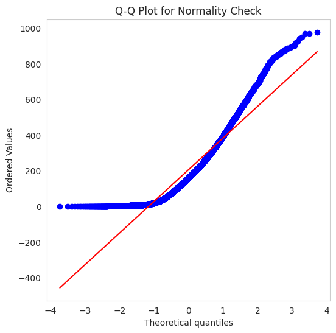

```
Normality Test:      Kolmogorov-Smirnov Test
Test Statistic:      1.3861e-01
P-value:             5.3978e-121

Reject H₀: Data is **not normally distributed**.


Weather 2
####################################################################################################
```

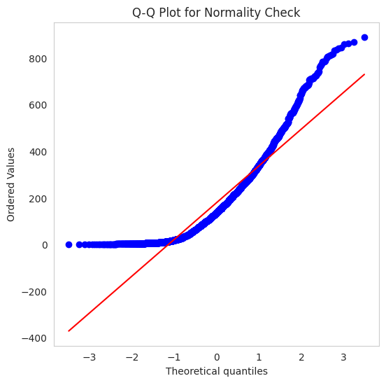

```
Normality Test:      Kolmogorov-Smirnov Test
Test Statistic:      1.4527e-01
P-value:             1.1787e-52

Reject H₀: Data is **not normally distributed**.


Weather 3
####################################################################################################
```

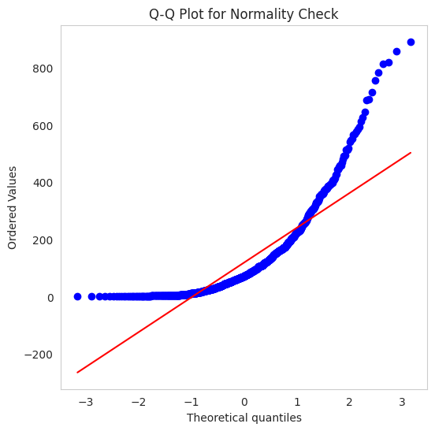

```
Normality Test:      Kolmogorov-Smirnov Test
Test Statistic:      1.9756e-01
P-value:             7.4572e-30

Reject H₀: Data is **not normally distributed**.


Weather 4
####################################################################################################
```

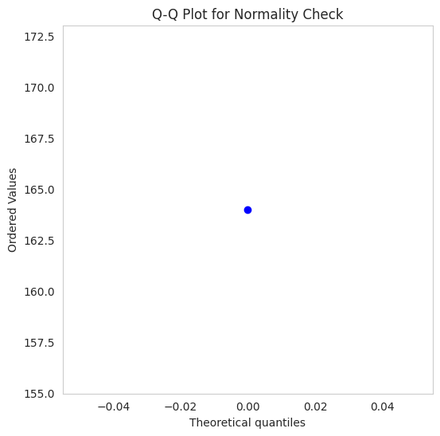

```
Normality Test:      Shapiro-Wilk Test
Test Statistic:      nan
P-value:             nan

Fail to reject H₀: Data appears **normally distributed**.




Variance Test:       Levene's Test
Test Statistic:      5.4851e+01
P-value:             3.5049e-35

Reject H₀: Variances are not equal.
```

```python
is_normal = True

for season in df['weather'].unique():
    print(f"Weather {season}")
    normal = normality_test(df[df['weather'] == season]['count'])
    if not normal:
        is_normal = False

variance_test('weather','count', is_normal)
```

Both normality and variance assumptions failed. Even so, lets use ANOVA as mentioned in question

```python
test_stat, p_value = stats.f_oneway(*[group['count'] for _, group in df.groupby('weather')])
print("\n")
print("*"*100)
print(f"{'ANOVA Test:':^100}")
print(f"{'Test Statistic':<20} {test_stat:<10.4e}")
print(f"{'P-value':<20} {p_value:<10.4e}")

if p_value < 0.05:
    print("\nReject H₀: The number of cycles rented significantly differs across weathers.")
else:
    print("\nFail to reject H₀: The number of cycles rented does not significantly differ across weathers.")
print("*"*100)
print("\n")
```

```
                                            ANOVA Test:
Test Statistic       6.5530e+01
P-value              5.4821e-42

Reject H₀: The number of cycles rented significantly differs across weathers.
```

### **ANOVA Test Insights**

- **Test Statistic**: The test statistic value is **65.53**, which is relatively large, indicating that there is a significant difference in the number of cycles rented across different weather conditions.
- **P-value**: The p-value is **5.48 × 10⁻⁴²**, which is extremely small. This suggests that the probability of observing such a difference if the null hypothesis were true is virtually zero. Hence, it provides very strong evidence against the null hypothesis.
- **Conclusion**: Since the p-value is far below the typical significance threshold (e.g., **α = 0.05**), we **reject the null hypothesis**. This means that the number of cycles rented **significantly differs** across different weather conditions.

### **Key Insights**

- Weather conditions have a **notable impact** on cycle rentals.
4. Weather is dependent on season (check between 2 predictor variable)

Null Hypothesis (H₀): Weather is independent of the season (no significant association).

Alternative Hypothesis (H₁): Weather is dependent on the season (there is a significant association).

```python
# Since both variables are categorical, we use chi-squared independence test

contingency_table = pd.crosstab(df['weather'], df['season'])
display(contingency_table)

print("\n\n")
print("*"*50)
print(f"{'Chi-Square Test for Independence':^100}")
chi2, p_value, dof, expected = stats.chi2_contingency(contingency_table)
print(f"{'Test Statistic':<20} {chi2:<10.4e}")
print(f"{'P-value':<20} {p_value:<10.4e}")
print(f"{'Degrees of Freedom':<20} {dof:<10}")

if p_value < 0.05:
    print("\nReject H₀: Weather is dependent on the season.")
else:
    print("\nFail to reject H₀: Weather is independent of the season.")
print("*"*50)
```

| season weather | 1 | 2 | 3 | 4 |
| --- | --- | --- | --- | --- |
| 1 | 1759 | 1801 | 1930 | 1702 |
| 2 | 715 | 708 | 604 | 807 |
| 3 | 211 | 224 | 199 | 225 |
| 4 | 1 | 0 | 0 | 0 |

```
                                  Chi-Square Test for Independence
Test Statistic       4.9159e+01
P-value              1.5499e-07
Degrees of Freedom   9

Reject H₀: Weather is dependent on the season.
```

```python
# Compute standardized residuals
observed = contingency_table.values  # Actual counts
standardized_residuals = (observed - expected) / np.sqrt(expected)

# Convert to DataFrame for better readability
residuals_df = pd.DataFrame(standardized_residuals, index=contingency_table.index, columns=contingency_table.columns)

# Display standardized residuals
display(residuals_df)
```

| season weather | 1 | 2 | 3 | 4 |
| --- | --- | --- | --- | --- |
| 1 | -0.369051 | -0.108200 | 2.927643 | -2.453131 |
| 2 | 0.595302 | -0.130984 | -4.029935 | 3.570104 |
| 3 | -0.065168 | 0.568089 | -1.134296 | 0.630696 |
| 4 | 1.516445 | -0.501055 | -0.501055 | -0.501147 |

Fall has significantly more clear weather than expected.

Likely due to stable atmospheric conditions, making it a preferred season for outdoor activities.

Winter has significantly fewer clear weather days, probably due to increased cloud cover.

Mist and Cloudy Conditions are strongly seasonal.

Winter has a much higher occurrence of mist than expected.

Fall has significantly fewer misty/cloudy days.

Cold air in Winter retains moisture, leading to more fog and mist.

Heavy Rain and Ice Pellets are slightly overrepresented in Spring.

This suggests spring storms are a notable weather pattern.

# Insights

Since the p-value is very small, we reject the null hypothesis (H₀) and conclude that weather is significantly dependent on the season.

Practical Implications:

Businesses relying on weather forecasts (e.g., tourism, outdoor rentals) can plan accordingly.

City planning and transportation services can optimize resource allocation based on expected seasonal weather patterns.

# Collated Insights and Recommendations

## Bussiness Insights

### Bivariate Analysis & Hypothesis Testing Insights

1. **Working Day vs. Cycle Rentals**
   - There is **no significant difference** in **average cycle rentals** between working and non-working days.
   - Other factors likely have a **greater influence** on cycle rentals than working status.
2. **Season vs. Cycle Rentals**
   - There is a **significant difference** in **cycle rentals across different seasons**.
3. **Weather vs. Cycle Rentals**
   - There is a **significant difference** in **cycle rentals across different weather conditions**.
4. **Weather vs. Season**
   - Weather patterns are **dependent on the season**.
   - **Fall has more clear days**, **winter has more misty/cloudy days**, and **spring shows slightly more heavy rain** than expected.

## Recommendations

```python
## END
```